# NBA Injuries

Michael Gillis

April 2023

# Packages

```r
library(tidyverse)
library(rvest)
library(tibble)
library(knitr)
library(tidymodels)
library(DT)
```

# Introduction

In American Sports Media, especially during coverage of the NBA, players are often criticized for their weight/size. One notable example of late is Chet Holmgren, whose 7’1” 195 lb frame has made him a target for those who say he is too skinny to play professional basketball (especially after his season-ending injury in the summer). On the other hand, Zion Williamson, a 22 year old who stands at 6’6”, 284 lb. Many of his detractors remark that he is too fat to play in the NBA, also citing injury issues.

So, it seems like an analysis of the relationship between injury and BMI in the NBA is warranted. To do this, we can make use of [data from Basketball Reference](https://www.kaggle.com/datasets/justinas/nba-players-data?select=all_seasons.csv) for player stats (like weight, height, etc.) and [data from Pro Sports Transactions](https://www.prosportstransactions.com/basketball/Search/Search.php) for injuries.

# Scrape and Load Data

## Injury Data

```r
# set base objects to scrape from
base_url <- "http://www.prosportstransactions.com/basketball/Search/SearchResults.php?Player=&Team=&BeginDate=2000-01-01&EndDate=2023-04-12&InjuriesChkBx=yes&Submit=Search"

base_webpage <- read_html(base_url)

new_urls <- "http://www.prosportstransactions.com/basketball/Search/SearchResults.php?Player=&Team=&BeginDate=2000-01-01&EndDate=2023-04-12&InjuriesChkBx=yes&Submit=Search&start=%s"

table_base <- html_table(base_webpage)[[1]] %>%
  as_tibble(.name_repair = "unique")

# make dataframes
table_new <- data.frame()
df <- data.frame()

# iterate through each page on the site and add new data to dataframe
i <- 0

while (i < 25426) {
  print(i)
  new_webpage <- read_html(sprintf(new_urls,i))
  table_new <- rvest::html_table(new_webpage)[[1]] %>%
    tibble::as_tibble(.name_repair = "unique") # repair the repeated columns
  df<- rbind(df,table_new)
  i=i+25
}

write.csv(injuries_freq, file = "data/injuries.csv")
```

In order for this document to render, we cannot scrape every single time we produce it. Thus, I saved the output as a .csv file which I can read now and get the same result.

```r
df <- read.csv("/Users/mgillis/Desktop/Projects/nba-injuries/data/injuries_scraped.csv")
```

Let’s glimpse this data:

```r
glimpse(df)
```

```
## Rows: 26,448
## Columns: 6
## $ X  <int> 1, 2, 3, 4, 5, 6, 7, 8, 9, 10, 11, 12, 13, 14, 15, 16, 17, 18, 19, …
## $ X1 <chr> "Date", "2000-01-03", "2000-01-03", "2000-01-04", "2000-01-04", "20…
## $ X2 <chr> "Team", "Celtics", "Warriors", "Celtics", "Grizzlies", "Grizzlies",…
## $ X3 <chr> "Acquired", "", "", "", "", "", "", "", "", "", "", "", "", "", "",…
## $ X4 <chr> "Relinquished", "• Dana Barros", "• Chris Mills", "• Dana Barros", …
## $ X5 <chr> "Notes", "flu (DNP)", "bone spurs in right ankle (DNP)", "flu (DNP)…
```

We’re going to want to clean this data a bit; change the column names, remove repeat headers, remove games missed due to illness or personal reasons, clean the names up (remove bullet points), etc.

```r
# rename columns
df <- df %>%
  rename(
    date = X1,
    team = X2,
    acquired = X3,
    name = X4,
    notes = X5
  )

# remove repeat headers, missed games due to illness, head coach injuries, and other miscellaneous issues
df <- subset(df, df$acquired == "" &
               df$name != "" &
               !(grepl("head coach", df$notes)) &
               !(grepl("illness", df$notes)) &
               !(grepl("flu", df$notes)) &
               !(grepl("virus", df$notes)) &
               !(grepl("health", df$notes)) &
               !(grepl("personal", df$notes)) &
               !(grepl("personal", df$notes)) &
               !(grepl("child", df$notes))
             )

# remove unwanted columns, clean names
df <- df %>%
  select(date, team, name, notes) %>%
  mutate(name = gsub("• ", "", name)) %>%
  mutate(name = gsub("\\s*\\([^\\)]+\\) ", "", name))
```

Now that this dataframe is clean, we can start to summarize it. We want each row to be a single NBA player, so we can use the `group_by` and `count` functions to do this.

```r
# summarize
injuries <- df %>%
  count(name, name = "injuries")
```

Finally, we have our dataframe looking exactly how we want it to. Let’s view it in a table.

```r
datatable(injuries)
```

|  | name | injuries |
| --- | --- | --- |
| 1 | A.J. Price | 19 |
| 2 | Aaron Brooks | 8 |
| 3 | Aaron Gordon | 15 |
| 4 | Aaron Gray | 3 |
| 5 | Aaron Holiday | 1 |
| 6 | Aaron McKie | 51 |
| 7 | Aaron Nesmith | 1 |
| 8 | Aaron Wiggins | 1 |
| 9 | Aaron Williams | 22 |
| 10 | Abdel Nader | 7 |

[output cut: 1564 more lines]

## Player Data

Now, to get the weight data, we can take the .csv file from https://www.kaggle.com/datasets/justinas/nba-players-data?select=all_seasons.csv

```r
df2 <- read.csv("/Users/mgillis/Desktop/Projects/nba-injuries/data/all_seasons.csv")
```

Again, let’s glimpse:

```r
glimpse(df2)
```

```
## Rows: 12,305
## Columns: 22
## $ X                 <int> 0, 1, 2, 3, 4, 5, 6, 7, 8, 9, 10, 11, 12, 13, 14, 15…
## $ player_name       <chr> "Dennis Rodman", "Dwayne Schintzius", "Earl Cureton"…
## $ team_abbreviation <chr> "CHI", "LAC", "TOR", "DAL", "MIA", "HOU", "LAL", "LA…
## $ age               <dbl> 36, 28, 39, 24, 34, 38, 25, 28, 29, 28, 27, 27, 28, …
## $ player_height     <dbl> 198.12, 215.90, 205.74, 203.20, 205.74, 200.66, 198.…
## $ player_weight     <dbl> 99.79024, 117.93392, 95.25432, 100.69742, 108.86208,…
## $ college           <chr> "Southeastern Oklahoma State", "Florida", "Detroit M…
## $ country           <chr> "USA", "USA", "USA", "USA", "USA", "USA", "USA", "US…
## $ draft_year        <chr> "1986", "1990", "1979", "1995", "1985", "1981", "199…
## $ draft_round       <chr> "2", "1", "3", "1", "1", "2", "1", "1", "Undrafted",…
## $ draft_number      <chr> "27", "24", "58", "9", "10", "29", "10", "27", "Undr…
## $ gp                <int> 55, 15, 9, 64, 27, 52, 80, 77, 71, 82, 9, 1, 13, 3, …
## $ pts               <dbl> 5.7, 2.3, 0.8, 3.7, 2.4, 8.2, 17.2, 14.9, 5.7, 6.9, …
## $ reb               <dbl> 16.1, 1.5, 1.0, 2.3, 2.4, 2.7, 4.1, 8.0, 1.6, 1.5, 0…
## $ ast               <dbl> 3.1, 0.3, 0.4, 0.6, 0.2, 1.0, 3.4, 1.6, 1.3, 3.0, 1.…
## $ net_rating        <dbl> 16.1, 12.3, -2.1, -8.7, -11.2, 4.1, 4.1, 3.3, -0.3, …
## $ oreb_pct          <dbl> 0.186, 0.078, 0.105, 0.060, 0.109, 0.034, 0.035, 0.0…
## $ dreb_pct          <dbl> 0.323, 0.151, 0.102, 0.149, 0.179, 0.126, 0.091, 0.1…
## $ usg_pct           <dbl> 0.100, 0.175, 0.103, 0.167, 0.127, 0.220, 0.209, 0.2…
## $ ts_pct            <dbl> 0.479, 0.430, 0.376, 0.399, 0.611, 0.541, 0.559, 0.5…
## $ ast_pct           <dbl> 0.113, 0.048, 0.148, 0.077, 0.040, 0.102, 0.149, 0.0…
## $ season            <chr> "1996-97", "1996-97", "1996-97", "1996-97", "1996-97…
```

We’re also going to want to clean this up. Fortunately, it will not take as much work as the other dataframe:

```r
df2 <- df2 %>%
  select(!c(X, team_abbreviation, age)) %>%
  rename(name = player_name) %>%
  mutate(player_weight = player_weight * 2.20462) %>%
  mutate(player_height = player_height * 0.393701) %>%
  mutate(bmi = (player_weight/(player_height^2))*703) %>%
  mutate(season = gsub("\\.-*", "", season)) %>%
  mutate(name = gsub("\\ /.*", "", name))
```

Now, we can summarize this cleaned data like we did for the other dataset. Now, we are collapsing the years, and again sorting by the player’s name.

```r
players <- df2 %>%
  group_by(name) %>%
  summarize(across(c(bmi, player_height, player_weight, gp, pts, reb, ast), mean)) %>%
  mutate(across(where(is.numeric), round, 2))
```

Finally, we have our second dataset read, cleaned, and summarized. Let’s view it in a table.

```r
datatable(players)
```

|  | name | bmi | player_height | player_weight | gp | pts | reb | ast |
| --- | --- | --- | --- | --- | --- | --- | --- | --- |
| 1 | A.C. Green | 24.11 | 81 | 225 | 75.8 | 5.78 | 6.06 | 0.86 |
| 2 | A.J. Bramlett | 23.73 | 82 | 227 | 8 | 1 | 2.8 | 0 |
| 3 | A.J. Guyton | 23.75 | 73 | 180 | 26.67 | 3.8 | 0.7 | 1.57 |
| 4 | AJ Hammons | 25.9 | 84 | 260 | 22 | 2.2 | 1.6 | 0.2 |
| 5 | AJ Price | 24.01 | 74 | 187 | 43.5 | 5.35 | 1.33 | 2 |
| 6 | Aaron Brooks | 21.83 | 72 | 161 | 64.5 | 8.88 | 1.55 | 2.76 |
| 7 | Aaron Gordon | 24.41 | 80.63 | 225.62 | 66 | 12.81 | 6.23 | 2.45 |
| 8 | Aaron Gray | 26.9 | 84 | 270 | 45.43 | 3.24 | 3.73 | 0.66 |
| 9 | Aaron Harrison | 24.27 | 78 | 210 | 11.67 | 2.6 | 1.33 | 0.63 |
| 10 | Aaron Henry | 24.9 | 77 | 210 | 6 | 0.3 | 0.2 | 0 |

[output cut: 2453 more lines]

## Merging Data

Now that we have our two dataframes with a shared variable, `name`, we can do an inner join. Note: Some players from the injury list do not appear on the list of players. This may be due to lack of games played, as some of the missing players only started in a few NBA games. Thus, we will use the `inner_join` function to combine these dataframes.

```r
full_table <- inner_join(injuries, players, by = "name")
```

Now we have our merged dataset, let’s view it in a table.

```r
datatable(full_table)
```

|  | name | injuries | bmi | player_height | player_weight | gp | pts | reb | ast |
| --- | --- | --- | --- | --- | --- | --- | --- | --- | --- |
| 1 | Aaron Brooks | 8 | 21.83 | 72 | 161 | 64.5 | 8.88 | 1.55 | 2.76 |
| 2 | Aaron Gordon | 15 | 24.41 | 80.63 | 225.62 | 66 | 12.81 | 6.23 | 2.45 |
| 3 | Aaron Gray | 3 | 26.9 | 84 | 270 | 45.43 | 3.24 | 3.73 | 0.66 |
| 4 | Aaron Holiday | 1 | 24.92 | 72.25 | 185 | 61.25 | 7.22 | 1.73 | 2.35 |
| 5 | Aaron McKie | 51 | 24.78 | 77 | 209 | 60.64 | 6.27 | 3 | 2.49 |
| 6 | Aaron Nesmith | 1 | 25.49 | 77 | 215 | 49 | 4.25 | 2.25 | 0.45 |
| 7 | Aaron Wiggins | 1 | 23.12 | 76 | 190 | 50 | 8.3 | 3.6 | 1.4 |
| 8 | Aaron Williams | 22 | 24.87 | 81 | 232.08 | 57.83 | 5.24 | 3.64 | 0.61 |
| 9 | Abdel Nader | 7 | 26.52 | 77.4 | 226 | 40.4 | 4.48 | 1.94 | 0.56 |
| 10 | Acie Law | 14 | 25.03 | 75 | 200.25 | 47 | 3.9 | 1 | 1.55 |

[output cut: 1372 more lines]

We can now begin to analyze this.

# Analysis

## Summary Stats

Let’s do some basic analysis and visualization of our variables of interest.

### BMI

Here’s a histogram of the distribution of BMI across the NBA:

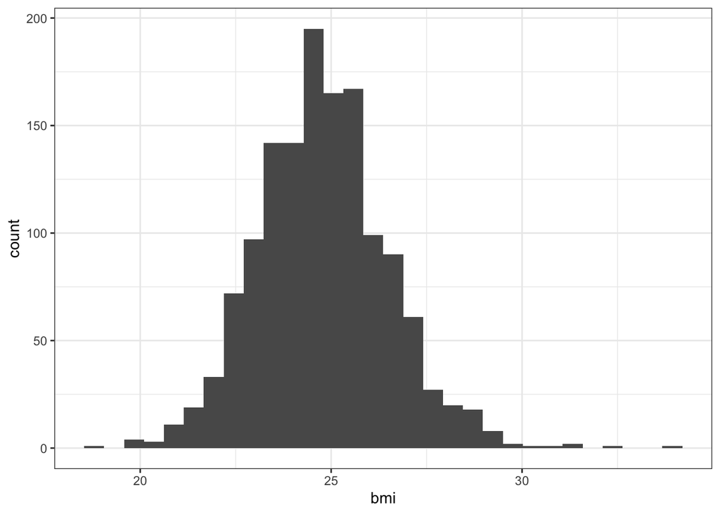

```r
full_table %>%
  ggplot(aes(x = bmi)) +
  geom_histogram() +
  theme_bw()
```

It looks to be relatively normal, so we will use **mean** and **standard deviation** to report the center and spread.

Here’s a list of the summary stats for BMI throughout the NBA:

```r
tibble(
  n = nrow(full_table),
  mean = mean(full_table$bmi),
  sd = sd(full_table$bmi),
  min = min(full_table$bmi),
  max = max(full_table$bmi)
)
```

```
## # A tibble: 1 × 5
##       n  mean    sd   min   max
##   <int> <dbl> <dbl> <dbl> <dbl>
## 1  1382  24.8  1.71  18.9  34.1
```

### Injuries

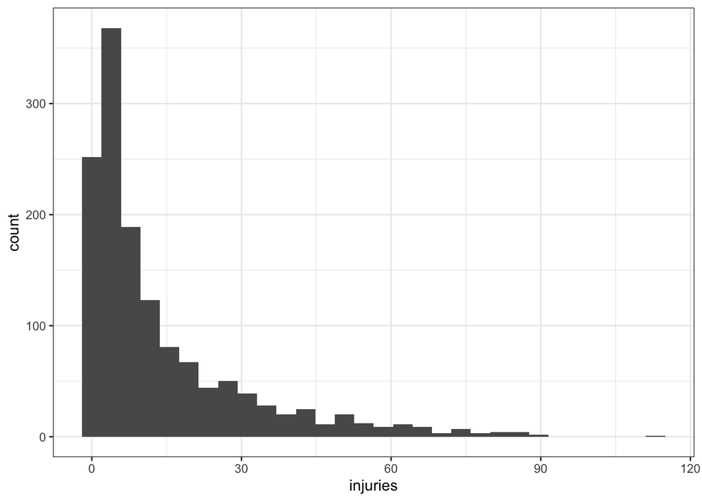

```r
full_table %>%
  ggplot(aes(x = injuries)) +
  geom_histogram() +
  theme_bw()
```

This distribution is heavily skewed, so we will use **median** and **IQR** as a measure of center and spread for injuries.

Here’s a list of the summary stats for injuries throughout the NBA:

```r
tibble(
  n = nrow(full_table),
  median = median(full_table$injuries),
  iqr = IQR(full_table$injuries),
  min = min(full_table$injuries),
  max = max(full_table$injuries)
)
```

```
## # A tibble: 1 × 5
##       n median   iqr   min   max
##   <int>  <dbl> <dbl> <int> <int>
## 1  1382      7    17     1   114
```

## Injuries vs. BMI

Now, let’s analyze the relationship between `injuries` and `bmi` using a scatterplot.

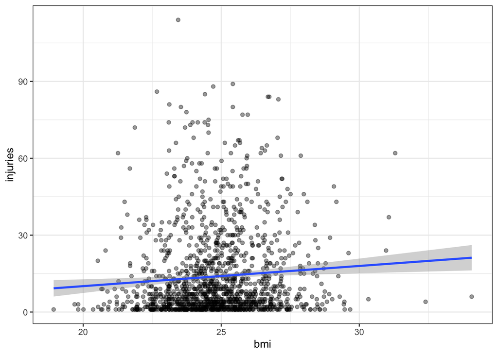

```r
full_table %>%
  ggplot(aes(x = bmi, y = injuries)) +
  geom_point(alpha = 0.4) +
  geom_smooth(method = "lm") +
  theme_bw()
```

We can see that this relationship does not even appear to be linear, implying that BMI is **not** a good predictor for number of injuries that a player will sustain over their career. Let’s take a look at some of the numbers from this model:

```r
injuries_bmi <- linear_reg() %>%
  set_engine("lm") %>%
  fit(injuries ~ bmi, data = full_table)

parsnip::tidy(injuries_bmi)
```

```
## # A tibble: 2 × 5
##   term        estimate std.error statistic p.value
##   <chr>          <dbl>     <dbl>     <dbl>   <dbl>
## 1 (Intercept)   -5.65      6.65     -0.850 0.395
## 2 bmi            0.788     0.268     2.94  0.00330
```

```r
glance(injuries_bmi)
```

```
## # A tibble: 1 × 12
##   r.squared adj.r.squ…¹ sigma stati…² p.value    df logLik    AIC    BIC devia…³
##       <dbl>       <dbl> <dbl>   <dbl>   <dbl> <dbl>  <dbl>  <dbl>  <dbl>   <dbl>
## 1   0.00624     0.00552  17.0    8.66 0.00330     1 -5872. 11751. 11766. 396982.
## # … with 2 more variables: df.residual <int>, nobs <int>, and abbreviated
## #   variable names ¹adj.r.squared, ²statistic, ³deviance
```

## Other Variables

Let’s make a function that can read any explanatory variable name and return a linear model with `injuries` as the response variable.

```r
lm_stats <- function(variable_of_interest){

  response_variable <- full_table %>%
    pull(injuries)

  explanatory_variable <- full_table %>%
    pull(variable_of_interest)

  new_df <- data.frame(response_variable, explanatory_variable)

  new_fit <- linear_reg() %>%
    set_engine("lm") %>%
    fit(response_variable ~ explanatory_variable, data = new_df )

  slope <- tidy(new_fit) %>%
    filter(term == "explanatory_variable") %>%
    pull(estimate)

  r_squared <- glance(new_fit) %>%
    pull(r.squared)

  p_value <- glance(new_fit) %>%
    pull(p.value)

  return(
    list(
      slope = slope,
      r_squared = r_squared,
      p_value = p_value
    )
  )

}
```

Now, we can use this function to iterate through each numeric variable and test it’s relationship with the `injuries` variable.

```r
variable_names <- full_table %>%
  select_if(is.numeric) %>%
  select(!injuries) %>%
  names()

injury_models <- data.frame(variable_names,slope = NA, r_squared = NA, p_value = NA)

row_index <- 1

for(row_index in 1:nrow(injury_models)){

  stats_results <- lm_stats(variable_of_interest = injury_models[row_index, "variable_names"])

  injury_models[row_index, "slope"] <- stats_results$slope
  injury_models[row_index,"r_squared"] <- stats_results$r_squared
  injury_models[row_index,"p_value"] <- stats_results$p_value

}

injury_models <- injury_models %>%
  mutate(across(where(is.numeric), round, 5))

datatable(injury_models)
```

|  | variable_names | slope | r_squared | p_value |
| --- | --- | --- | --- | --- |
| 1 | bmi | 0.78779 | 0.00624 | 0.0033 |
| 2 | player_height | 0.13841 | 0.00081 | 0.29179 |
| 3 | player_weight | 0.04568 | 0.005 | 0.00853 |
| 4 | gp | 0.3355 | 0.11885 | 0 |
| 5 | pts | 1.49896 | 0.17786 | 0 |
| 6 | reb | 3.0418 | 0.12877 | 0 |
| 7 | ast | 3.59376 | 0.09843 | 0 |

Once again, we can see that `bmi` or even `player_weight` and `player_height` are **not** good predictors for injury count. In fact, the variable with the highest r squared value is `pts`, with a slope of about `1.5`, implying that the more points you score, the predicted number of injuries in our model increases.